# Homework 6: Hypothesis Testing

Please complete this notebook by filling in the cells provided. When you’re done:

1. Select `Run All` from the `Cell` menu to ensure that you have executed all cells.
2. Select `Download as HTML (.html)` from the `File` menu
3. Inspect your file to make sure it looks like it should.
4. Upload your file to Moodle.

```python
# Run this cell to set up the notebook, but please don't change it.
import numpy as np
from datascience import *

# These lines do some fancy plotting magic.
import matplotlib
%matplotlib inline
import matplotlib.pyplot as plt
plt.style.use('fivethirtyeight')
import warnings
warnings.simplefilter('ignore', FutureWarning)
```

## 1. Catching Cheaters

Suppose you are a casino owner, and your casino runs a very simple game of chance. The customer names heads or tails, and then a dealer flips a coin. The customer wins 9 USD from the casino if they guess the right side and loses 10 USD if they're wrong.

#### Question 1

Assuming no one is cheating and the coin is fair, if a customer bets once on heads, what is the chance they win that bet? Over many bets on heads, what is the average amount of money the customer wins from a single bet? Does your answer change if they bet on tails instead?

If a customer bets once on heads, the chance they win the bet is 1/2. Since the probability to get the heads from a single bet is 1/2, the average chance of winning is 1/2 which has the same number of wins and loses. The customer gets 9 dollars for winning and loses 10 dollars for losing. Therefore, if we assume the customer to have the same number of wins and loses, they can getthe average -0.5 USD from a single bet. since there is only two choices with equal chance, they will get the same average amount of money even when they bet on tails instead of the heads.

A certain customer plays the game 20 times, betting heads each time, and wins 13 of the bets. You suspect that the customer is cheating! That is, you think that their chance of winning could be something other than the normal chance of winning.

You decide to test this using the outcomes of the 20 games you observed.

#### Question 2

Define the null hypothesis and alternative hypothesis for this investigation.

null hypothesis = the customer did not cheat. the probability to win or lose are both 1/2.

alternative hypothesis = there is a chance for the customer to cheat.

#### Question 3

Define a test statistic function named `test_statistic`. Your function should take as its argument the number of times the customer won. It should return the value of the test statistic for those data. You'll have to decide how to define the test statistic. **Then**, compute the value of your test statistic for the 20 games played by the customer we're investigating. Call this number `actual_test_statistic`.

```python
def test_statistic(num_wins):
    '''take the number of times the customer won
    and return the value of the test statistic for the data'''
    observed_statistic = abs ((num_wins / 20) - 0.5)
    return observed_statistic

## the customer won 13 times for 20 games
actual_test_statistic = test_statistic(13)
actual_test_statistic
```

```
0.15000000000000002
```

#### Question 4

Write a function called `simulate_under_null`. It should take no arguments. It should return the number of wins in 20 games simulated under the assumption that the null hypothesis is true. (That number is random.)

```python
def simulate_under_null():
    '''return the number of wins in 20 games assuming that the null hypothesis is true'''
    proportions = sample_proportions(20, make_array(.5,.5))
    number_of_wins = 20*proportions.item(0)
    return int(number_of_wins)

simulate_under_null()
```

```
11
```

#### Question 5

Run your simulation 10,000 times and make a histogram of the test statistics. (Be sure to pick bins that accurately portray the distribution.)

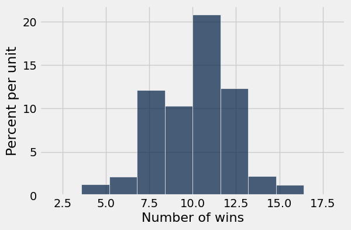

```python
sampled_stats = make_array()
repetition = 10000

for i in np.arange(repetition):
    game_simulation = simulate_under_null()
    sampled_stats = np.append(sampled_stats, game_simulation)
sampled_stats

null_dist = Table().with_column('Number of wins', sampled_stats)
null_dist.hist()
```